# Flights Data Exploration

## by: Fahad Almani

## Investigation Overview

> Today I want to show my investigation, in this investigation, I try to understand the flights delay and where the delay factor on flights in the united states in 2008, some factors I use in my investigation (AirTime, ActualElapsedTime, CRSElapsedTime, DayOfWeek, .... ).

## Dataset Overview

> The dataset used in the investigation is the United States flights, this dataset was collected in 2008, there are 7M recorded approximately and 29 columns after cleaning we have 6.85M records approximately 10 columns

## The distrbution of flights for each day of week

> There is no big difference between (Monday, Tuesday, Wednesday, Thursday, and Friday) flights, all days have approximately the same number of flights except Sunday and Saturday in fact, the number of flights on Sunday is greater than the number of flights on Saturday but all Sunday and Saturday are less than other days of the week.

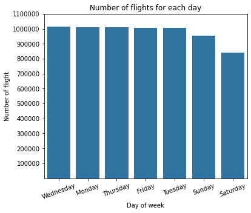

## The distrbution of flights for each flights carrier

> There are 20 United state flights carriers in my investigation there big differences between all flights carriers in flights number, like 'WN' have a lot of flights except other flights carriers like 'AQ' they have a little of flights, maybe 'WN' is large than AQ but in this investigation don't have data about each flight carrier individually.

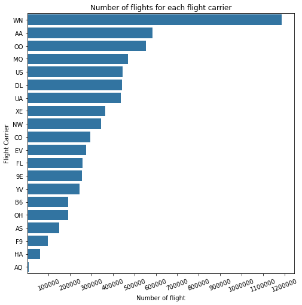

## The relation between AirTime and ActualElapsedTime

> In this figure, you can see when actual elapsed time increases the air time increase that's mean the preparation for flights it's not the delay main effect. the air traffic and distance is the delay main effect

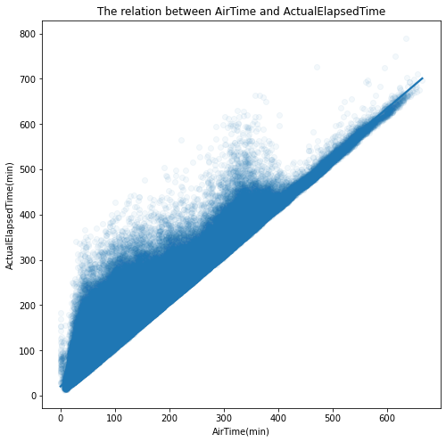